```python
import pandas as pd
import numpy as np
import random
import csv
from matplotlib import pyplot as plt
import seaborn as sns
import category_encoders as ce
import warnings
from sklearn.impute import KNNImputer
from sklearn.metrics import mean_squared_error
warnings.filterwarnings('ignore')
```

# 1. Kodowanie zmiennych kategorycznych

Wczytuję dane i zmieniam wszystkie litery na małe

```python
allegro=pd.read_csv("allegro-api-transactions.csv")
allegro["it_location"]=allegro["it_location"].apply(str.lower)
```

# TargetEncoding

```python
target=ce.TargetEncoder()
allegro["it_location_targetencoding"]=target.fit_transform(allegro["it_location"],allegro["price"])
allegro["it_location_targetencoding"].head()
```

```
0    84.132898
1    84.132898
2    64.883187
3    35.433365
4    73.772916
Name: it_location_targetencoding, dtype: float64
```

Jak widać dla dla każdej kateogorii została przypisana wartość liczbowa. Gdybyśmy użyli One-hot encodingu powstałyby 7903 nowe kolumny, ponieważ tyle mamy unikalnych kategorii i z tego względu Target Encoding wydaje się być lepszy. Z drugiej strony zamiana na pojedyńczą wartość numeryczną wprowadza pewnego rodzaju uporządkowanie i daje możliwość porównywania, której nie było w pierwotnych danych.

TargetEncoding przypisuje każdej z kategorii, średnią wartość zmiennej objaśnianej dla tej kategorii.

```python
allegro[["main_category"]].describe()
```

|  | main_category |
| --- | --- |
| count | 420020 |
| unique | 27 |
| top | Dom i Ogród |
| freq | 91042 |

# OneHotEncoding

```python
onehot=ce.OneHotEncoder()
onehot_df=pd.read_csv("allegro-api-transactions.csv")
onehot_df=onehot_df.join(onehot.fit_transform(allegro["main_category"]))
onehot_df.head()
```

|  | lp | date | item_id | categories | pay_option_on_delivery | pay_option_transfer | seller | price | it_is_allegro_standard | it_quantity | ... | main_category_18 | main_category_19 | main_category_20 | main_category_21 | main_category_22 | main_category_23 | main_category_24 | main_category_25 | main_category_26 | main_category_27 |
| --- | --- | --- | --- | --- | --- | --- | --- | --- | --- | --- | --- | --- | --- | --- | --- | --- | --- | --- | --- | --- | --- |
| 0 | 0 | 2016-04-03 21:21:08 | 4753602474 | ['Komputery', 'Dyski i napędy', 'Nośniki', 'No... | 1 | 1 | radzioch666 | 59.99 | 1 | 997 | ... | 0 | 0 | 0 | 0 | 0 | 0 | 0 | 0 | 0 | 0 |
| 1 | 1 | 2016-04-03 15:35:26 | 4773181874 | ['Odzież, Obuwie, Dodatki', 'Bielizna damska',... | 1 | 1 | InwestycjeNET | 4.90 | 1 | 9288 | ... | 0 | 0 | 0 | 0 | 0 | 0 | 0 | 0 | 0 | 0 |
| 2 | 2 | 2016-04-03 14:14:31 | 4781627074 | ['Dom i Ogród', 'Budownictwo i Akcesoria', 'Śc... | 1 | 1 | otostyl_com | 109.90 | 1 | 895 | ... | 0 | 0 | 0 | 0 | 0 | 0 | 0 | 0 | 0 | 0 |
| 3 | 3 | 2016-04-03 19:55:44 | 4783971474 | ['Książki i Komiksy', 'Poradniki i albumy', 'Z... | 1 | 1 | Matfel1 | 18.50 | 0 | 971 | ... | 0 | 0 | 0 | 0 | 0 | 0 | 0 | 0 | 0 | 0 |
| 4 | 4 | 2016-04-03 18:05:54 | 4787908274 | ['Odzież, Obuwie, Dodatki', 'Ślub i wesele', '... | 1 | 1 | PPHU_RICO | 19.90 | 1 | 950 | ... | 0 | 0 | 0 | 0 | 0 | 0 | 0 | 0 | 0 | 0 |

5 rows × 41 columns

OneHotEncoding stworzył 27 nowych kolum odpowiadających 27 unikalnym kategoriom z "main_category". Nie mamy teraz problemu ze storzeniem sztucznego porządku podczas enncodingu dzięki czemu model nie będzie ich porównywał tak jak w przypadku gdy zastąpiliśmy kategorię jedną wartością.

# OrdinalEncoding

```python
ordinal=ce.OrdinalEncoder()
ordinal_df=pd.read_csv("allegro-api-transactions.csv")
ordinal_df["main_category_ordinal"]=ordinal.fit_transform(allegro["main_category"])
ordinal_df["main_category_ordinal"].head()
```

```
0    1
1    2
2    3
3    4
4    2
Name: main_category_ordinal, dtype: int32
```

OrdinalEncoding działa na zasadzie przyporządkowania każdej kategorii losowej liczby całkowitej.Użycie tego pozostawia problem tworzenia sztucznego pożądku.

# HashingEncoding

```python
hashing=ce.HashingEncoder()
hashing_df=pd.read_csv("allegro-api-transactions.csv")
hashing_df=hashing_df.join(hashing.fit_transform(allegro["main_category"]))
hashing_df.head()
```

|  | lp | date | item_id | categories | pay_option_on_delivery | pay_option_transfer | seller | price | it_is_allegro_standard | it_quantity | ... | it_location | main_category | col_0 | col_1 | col_2 | col_3 | col_4 | col_5 | col_6 | col_7 |
| --- | --- | --- | --- | --- | --- | --- | --- | --- | --- | --- | --- | --- | --- | --- | --- | --- | --- | --- | --- | --- | --- |
| 0 | 0 | 2016-04-03 21:21:08 | 4753602474 | ['Komputery', 'Dyski i napędy', 'Nośniki', 'No... | 1 | 1 | radzioch666 | 59.99 | 1 | 997 | ... | Warszawa | Komputery | 0 | 0 | 0 | 0 | 0 | 0 | 1 | 0 |
| 1 | 1 | 2016-04-03 15:35:26 | 4773181874 | ['Odzież, Obuwie, Dodatki', 'Bielizna damska',... | 1 | 1 | InwestycjeNET | 4.90 | 1 | 9288 | ... | Warszawa | Odzież, Obuwie, Dodatki | 0 | 0 | 1 | 0 | 0 | 0 | 0 | 0 |
| 2 | 2 | 2016-04-03 14:14:31 | 4781627074 | ['Dom i Ogród', 'Budownictwo i Akcesoria', 'Śc... | 1 | 1 | otostyl_com | 109.90 | 1 | 895 | ... | Leszno | Dom i Ogród | 0 | 0 | 0 | 0 | 0 | 0 | 1 | 0 |
| 3 | 3 | 2016-04-03 19:55:44 | 4783971474 | ['Książki i Komiksy', 'Poradniki i albumy', 'Z... | 1 | 1 | Matfel1 | 18.50 | 0 | 971 | ... | Wola Krzysztoporska | Książki i Komiksy | 0 | 0 | 1 | 0 | 0 | 0 | 0 | 0 |
| 4 | 4 | 2016-04-03 18:05:54 | 4787908274 | ['Odzież, Obuwie, Dodatki', 'Ślub i wesele', '... | 1 | 1 | PPHU_RICO | 19.90 | 1 | 950 | ... | BIAŁYSTOK | Odzież, Obuwie, Dodatki | 0 | 0 | 1 | 0 | 0 | 0 | 0 | 0 |

5 rows × 22 columns

HashingEncoding zamienia każdą kategorię na n-wymiarowy wektor wypełniony 0 i 1. Mając kontrolę nad n możemy uniknąć robienia wielu kolum jak w onehot ale narażamy się na to, że dwie kategoie będą miały tego samego hasha.

# 2. Uzupełnianie braków

```python
random.seed(11111)
imputer=KNNImputer(n_neighbors=2, weights="uniform")
allegro2=pd.read_csv("allegro-api-transactions.csv")[["price", "it_seller_rating", "it_quantity"]]
allegro2=allegro2[0:42000]
RMSE=[0 for i in range(10)]
for i in range(10):
    remove_index=random.sample(range(0,42000),4200)
    allegro2_removed=allegro2.copy()
    allegro2_removed.iloc[remove_index,1]=None
    allegro2_imputed=pd.DataFrame(imputer.fit_transform(allegro2_removed),columns=["price", "it_seller_rating", "it_quantity"])
    RMSE[i]=mean_squared_error(allegro2["it_seller_rating"],allegro2_imputed["it_seller_rating"],squared=False)
print("RMSE: ",RMSE)
print("Std: ",np.std(RMSE))
```

```
RMSE:  [11443.754509280016, 11411.141702223586, 11342.007484569727, 10933.83644652739, 11318.875938514484, 11906.28048871062, 11287.93011787923, 11306.438861907036, 11008.410856945226, 10668.978986442089]
Std:  317.22632045102193
```

```python
RMSE1=[0 for i in range(10)]
RMSE2=[0 for i in range(10)]
for i in range(10):
    remove_index1=random.sample(range(0,42000),4200)
    remove_index2=random.sample(range(0,42000),4200)
    allegro2_removed=allegro2.copy()
    allegro2_removed.iloc[remove_index1,1]=None
    allegro2_removed.iloc[remove_index2,2]=None
    allegro2_imputed=pd.DataFrame(imputer.fit_transform(allegro2_removed),columns=["price", "it_seller_rating", "it_quantity"])
    RMSE1[i]=mean_squared_error(allegro2["it_seller_rating"],allegro2_imputed["it_seller_rating"],squared=False)
    RMSE2[i]=mean_squared_error(allegro2["it_quantity"],allegro2_imputed["it_quantity"],squared=False)
print("RMSE it_seller_rating: ",RMSE1)
print("RMSE it_quantity: ",RMSE2)
print("Std RMSE it_seller_rating: ",np.std(RMSE1))
print("Std RMSE it_quantity: ",np.std(RMSE2))
```

```
RMSE it_seller_rating:  [13060.299587905525, 13091.145805401215, 12683.553615826115, 12974.49757203691, 13283.02125238761, 12447.259397071633, 12750.905913463794, 12182.394416401883, 13286.834397583329, 12957.094668321033]
RMSE it_quantity:  [8929.926087860347, 8925.032571759293, 8558.190040450045, 8521.033608293461, 8690.771482639748, 8448.170548486547, 8743.05596912521, 8333.195716894299, 9127.279514673372, 8524.590357926787]
Std RMSE it_seller_rating:  338.87901723069535
Std RMSE it_quantity:  237.683222351418
```

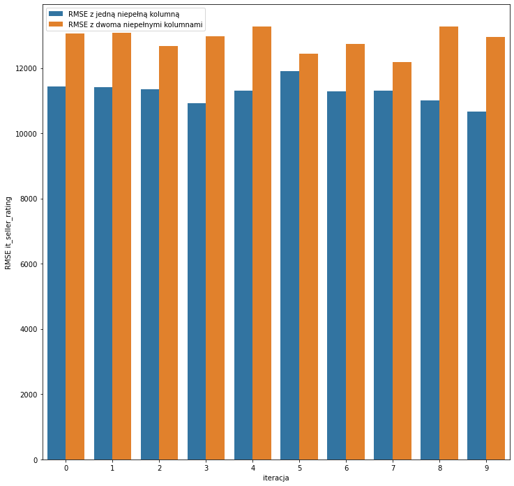

```python
d={'RMSE it_seller_rating':RMSE+RMSE1,'iteracja':[0,1,2,3,4,5,6,7,8,9,0,1,2,3,4,5,6,7,8,9],'col2':["RMSE z jedną niepełną kolumną" for i in range(10)]+["RMSE z dwoma niepełnymi kolumnami" for i in range(10)]}
df=pd.DataFrame(data=d)
fig=plt.figure(figsize=(12,12))
g=sns.barplot(x='iteracja',y='RMSE it_seller_rating',hue='col2',data=df)
g.legend_.set_title(None)
```

Z powyższego wykresu wyraźnie widać, że po usunięciu 10% wartości z innej kolumny algorytm imputacji działa zauważalnie gorzej. Używanie automatycznego wypełniania braków np. KNNimutation wiąże się z dużym błędem oraz odchyleniem standardowym, rosnącym wraz z ilością kolumn, w których te braki występują.